# Creating a plot of SST along a transect line

The goal is to make a plot of SST along a transect line. The motivation behind this is to show the spatio-temporal pattern of the SST fronts off the coast of Kochi.

## Set up the transect

First we will set up our transect with points (lat/lon) every 10km on this line. This will use the **data.table**, **geotools** and **geosphere** packages to create equispaced points between two lat/lon points.

Here is the transect line drawn on top of the bathymetry off the west coast. We use the **marmap** package to download bathymetry data and plot.

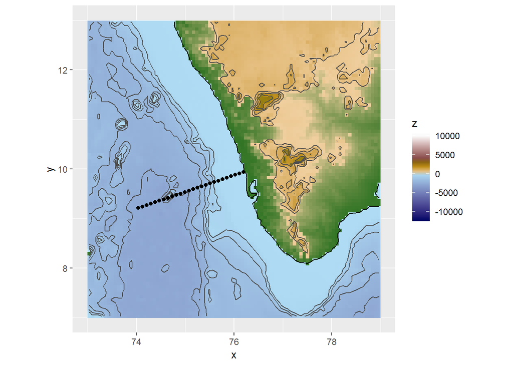

## Download SST along the transect

The satellite data are taken from the ERDDAP server at http://coastwatch.pfeg.noaa.gov/erddap/

### Install the rerddap packages if needed

Load the packages.

For convenience, make shorter names for the latitude and longitude data.

Set the date to use.

We will use the SST, Pathfinder Ver 5.2 (L3C), Day, Global, 0.0417°, 1981-2012, Science Quality (Monthly Composite). 0.0417 degrees is 4.63km approx.

Look at DataInfo to see if dataset has an altitude dimension. If it does, then the call to `rxtracto()` must define `zcoord`, if it doesn’t then the call should not give `zcoord`.

Match up satellite data with the trackdata.

After it has completed the extraction the data.frame ‘swchl’ will contain as many columns as datapoints in the input file and will have the following names:

- mean = mean of data within search radius
- stdev = standard deviation of data within search radius
- n = number of points found within search radius
- satellite date = time of returned value
- requested lon min = min longitude of call (decimal degrees)
- requested lon max = max longitude of call (decimal degrees)
- requested lat min = min latitude of call (decimal degrees)
- requested lat max = max latitude of call (decimal degrees)
- requested date = requested time in tag
- median = median of data within search radius
- mad = median absolute deviation of data within search radius

Shorten variable name for ease in referencing

Now make some plots of the data. First combine the two dataframes into one, so it will be easy to take into account the locations that didn’t retrieve a value.

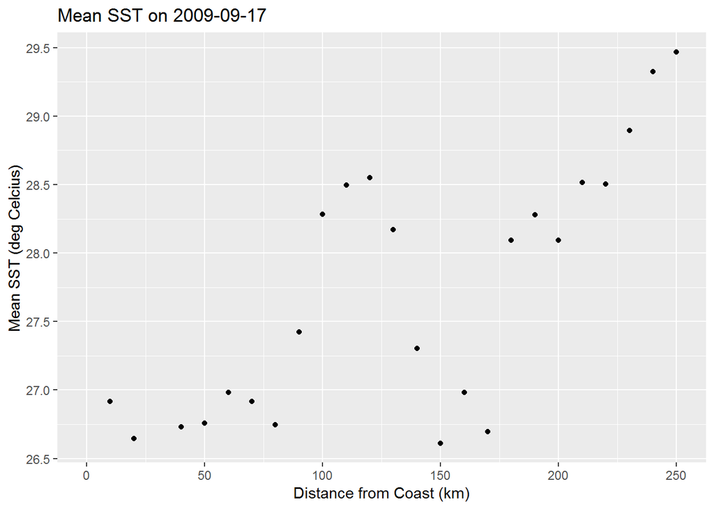

## Create a colorbar of the values

First we associate a color with the range of SST values. We’ll fill in the NAs for chlorophyll with `approx()` (linear interpolation).

Create colors for each level of SST. Dark blue is cold (low); red is hot (high).

Plot the colorbar with time on the axis. The data we used was 1-month averages so the colorbar width is set at 1-month.

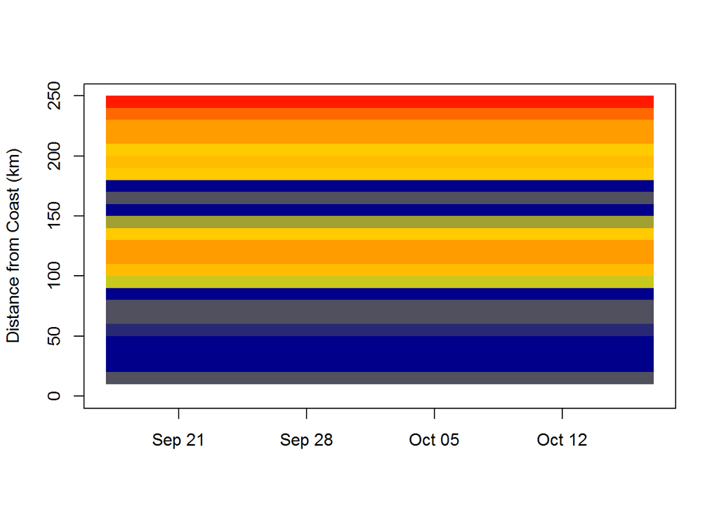

## Create colorbars for the whole year

Now we will put these pieces together to make a plot of the SST gradient throughout the year. Here the NAs are left as is.

We want to get the SST data for the transect at each date. We will store this in a matrix.

Create a matrix like `meanmat` but with color for each value in `meanmat`.

Now plot strips for each 1-month window. We will set the margin to leave some room for a colorbar. We will add a colorbar at the bottom using the `set.colorbar()` function in the **oceanmap** package. We need to fiddle a little with the `cby` value to get it in the right place.

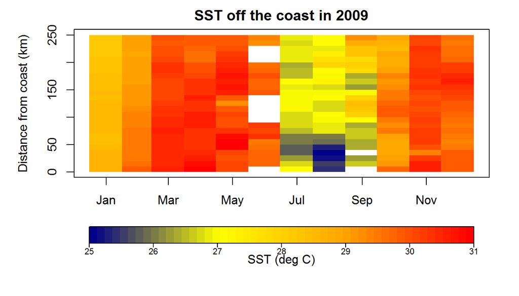